# permutation testing in the tidyverse

Luke Reding

10/4/2017

## to do

- figure out the influence of unequal sample sizes

## why? and some definitions

**bootstrapping**: sampling *with replacement* from your data. Mostly useful for getting a confidence interval or seeing the variation inherent some test statistic of interest.

**permutation testing:** creating all possible permutations of your data, calcualating some test statistic each time to generate a null distribution of test statistics, and comparing the observed results to this distribution. Because permutation testing is often not feasible for larger datasets, I stop talking about it here.

**monte carlo sampling:** Similar to permutation testing, but uses random or psudo-random numbers to randomly permute the dataset to generate a null distribution and compare the distribution to the observed test statistic.

This document really only covers ‘modern’ methods of bootstrapping and monte carlo sampling.

#### advantages:

- makes few assumptions, espeically about the form of the distribution from which the data are draw (e.g. normally distributed)
- p-values are intuitve to calculate and understand
- seems like magic

#### disadvantages:

- p-values can change when you re-reun the analysis (but can change less if you increase the number of times you permute the dataset)
- fewer resources on running permutation tests / less entrenched in the culture of hypothesis testing

## some recipes for common use cases

```r
library(tidyverse)
library(modelr)
library(broom)
```

### bootstrapping

Let’s say we want to bootstrap a confidence interval for the relatiosnip between a car’s weight and mpg:

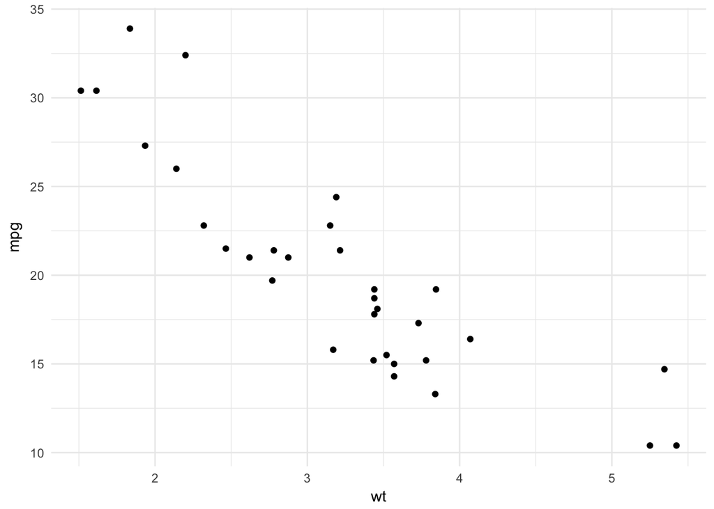

```r
ggplot(mtcars, aes(x = wt, y = mpg)) +
  geom_point() +
  theme_minimal()
```

We can run a linear model and add the model predictions to the plot easily with `modelr` functions:

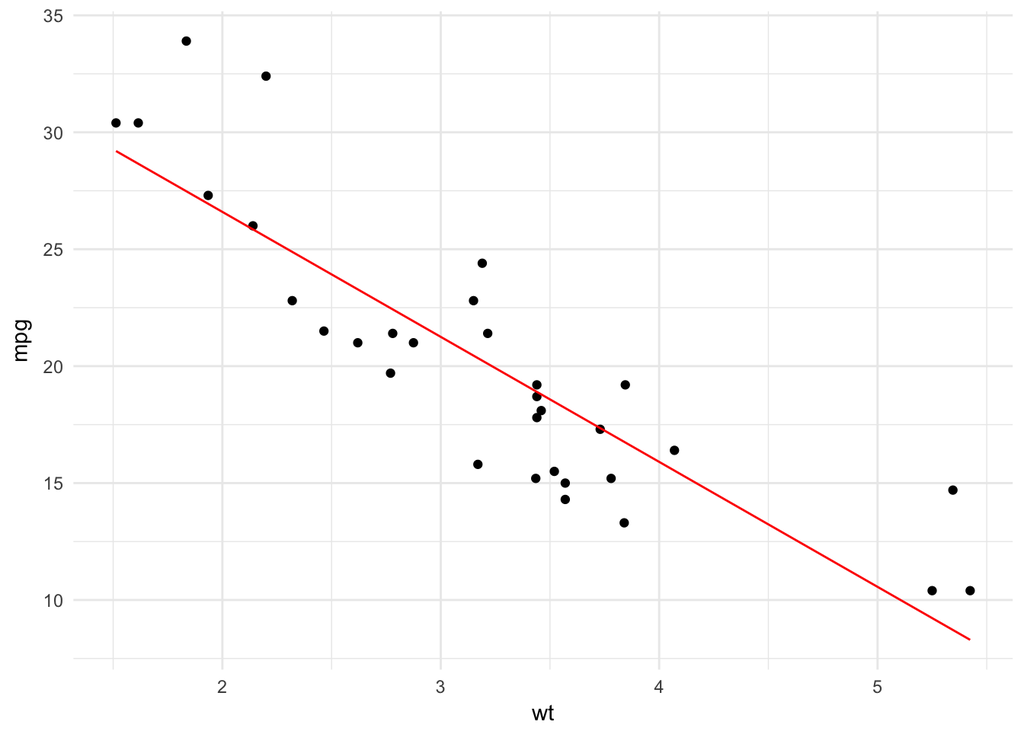

```r
mod <- lm(mpg ~ wt, data = mtcars)

mtcars %>%
  add_predictions(mod) %>%
  ggplot(aes(x = wt, y = mpg)) +
  geom_point() +
  geom_line(aes(y = pred), color = "red") +
  theme_minimal()
```

Now we can bootstrap out dataset–i.e., sampling the rows from the dataset with replacement–to get a sense of the confidence in our prediction in the regression. I do this using the `bootstap` function from `modelr` (though there is also a function by this name in the `broom` package, which is why I use the `::` notation below):

```r
library(purrr)

resampled <-  mtcars %>%
  modelr::bootstrap(100) %>%
  mutate(models = map(strap, ~ lm(mpg ~ wt, data = .)))

head(resampled)
```

```
## # A tibble: 6 x 3
##            strap   .id   models
##           <list> <chr>   <list>
## 1 <S3: resample>   001 <S3: lm>
## 2 <S3: resample>   002 <S3: lm>
## 3 <S3: resample>   003 <S3: lm>
## 4 <S3: resample>   004 <S3: lm>
## 5 <S3: resample>   005 <S3: lm>
## 6 <S3: resample>   006 <S3: lm>
```

The above code is a bit complex but very powerful. `modelr::bootstrap(100)` creates 100 different bootstrap replicates of the dataset. Each resampling gets in own row in the resulting dataframe in the column that is named `strap`.

From there, we use the powerhouse combination of `mutate` with `map`. This is a common series of functions when working with dataframes in which some of the columns are lists (as the `strap` column is). The combination allows us to go into each of the lists, in this case in the `strap` column, and perform some function or extract some statistic we care about. `mutate` adds a column to the dataframe while `map` allows up to apply the operation to all the rows without having to use a loop.

The call to `map` from within `mutate` is pretty typical: `map(strap, ~ lm(mpg ~ wt, data = .)`. The first argument, `strap` is the column that we want to pull something out of, or do something with. The second argument is a function; in this case the function is creating a linear model. The output of the linear model–which is, again, a list–will be saved to a new column called `models`.

The `broom` package easily lets us extract usful things (fits, p-values, estimates of parameters) from model objects like the linear models we created and saved to the `models` column:

```r
resampled_with_stats <- resampled %>%
  mutate(tidy= map(models, broom::glance)) %>%
  unnest(tidy)

head(resampled_with_stats)
```

```
## # A tibble: 6 x 14
##            strap   .id   models r.squared adj.r.squared    sigma statistic
##           <list> <chr>   <list>     <dbl>         <dbl>    <dbl>     <dbl>
## 1 <S3: resample>   001 <S3: lm> 0.7121879     0.7025941 3.124466  74.23466
## 2 <S3: resample>   002 <S3: lm> 0.7001421     0.6901468 3.418255  70.04738
## 3 <S3: resample>   003 <S3: lm> 0.7579885     0.7499215 3.459248  93.96105
## 4 <S3: resample>   004 <S3: lm> 0.7810812     0.7737839 2.912621 107.03708
## 5 <S3: resample>   005 <S3: lm> 0.6710206     0.6600546 3.041056  61.19111
## 6 <S3: resample>   006 <S3: lm> 0.7254233     0.7162707 2.807162  79.25909
## # ... with 7 more variables: p.value <dbl>, df <int>, logLik <dbl>,
## #   AIC <dbl>, BIC <dbl>, deviance <dbl>, df.residual <int>
```

By applying `glance` to each of the models then `unnest`ing the list-column, we have a nice dataframe with the r squared value, p-value, etc for each model, which we can then easily plot:

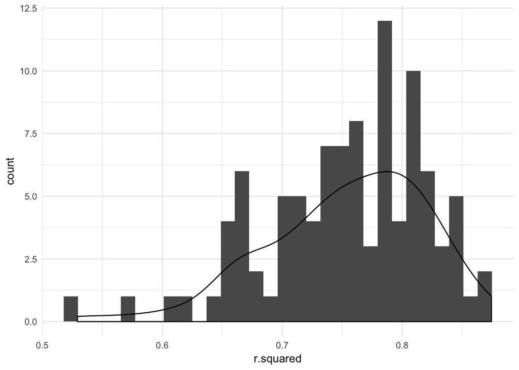

```r
resampled_with_stats %>%
  ggplot(aes(x = r.squared)) +
  geom_histogram() +
  geom_density() +
  theme_minimal()
```

We can also plot all the regressions on our original plot. This requires a slightly different approach, since `modelr::bootstrap` stores a pointer to the bootstrapped dataframes and not the actual dataframe:

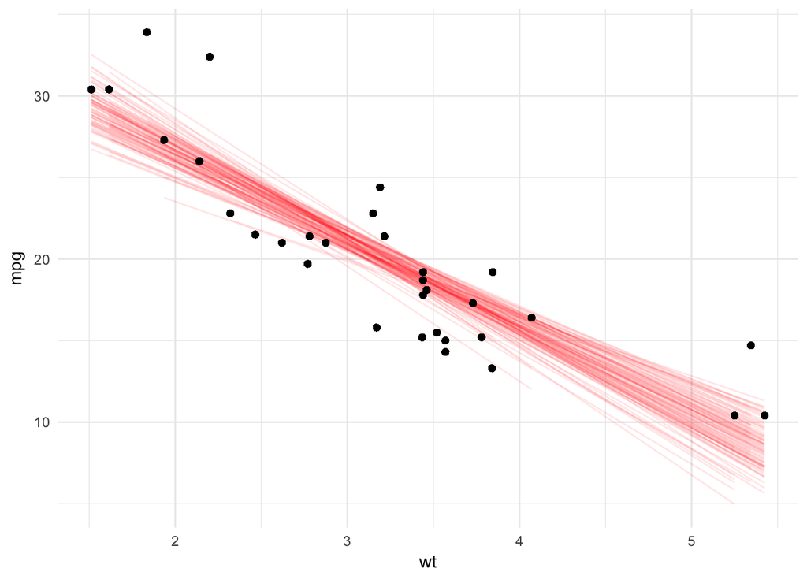

```r
mtcars %>%
  broom::bootstrap(100) %>%
  do(augment(lm(mpg ~ wt, data = .), .)) %>%
  ggplot(aes(x = wt, y = mpg)) +
  geom_line(aes(y = .fitted, group = replicate), color = "red", alpha = 0.1) +
    geom_point() +
  theme_minimal()
```

### correlation

For a correlation, we might be interested in two different things:

1. Bootstrapping a confidence interval around our estimate of the correlation coefficient or
2. Determining whether a non-zero correlation exists using permutation testing.

I cover each below.

#### :: bootstrapping a confidence interval

This largely follows the appraoch we took above:

```r
mtcars %>%
  broom::bootstrap(100) %>%
  do(glance(cor.test(.$wt, .$mpg))) %>%
  pull(estimate) %>%
  quantile(., probs = c(0.025, 0.975))
```

```
##       2.5%      97.5%
## -0.9197673 -0.7960015
```

That’s the 95% confidence interval for the correlation coefficient. We can also plot the distribution of correlation coefficient:

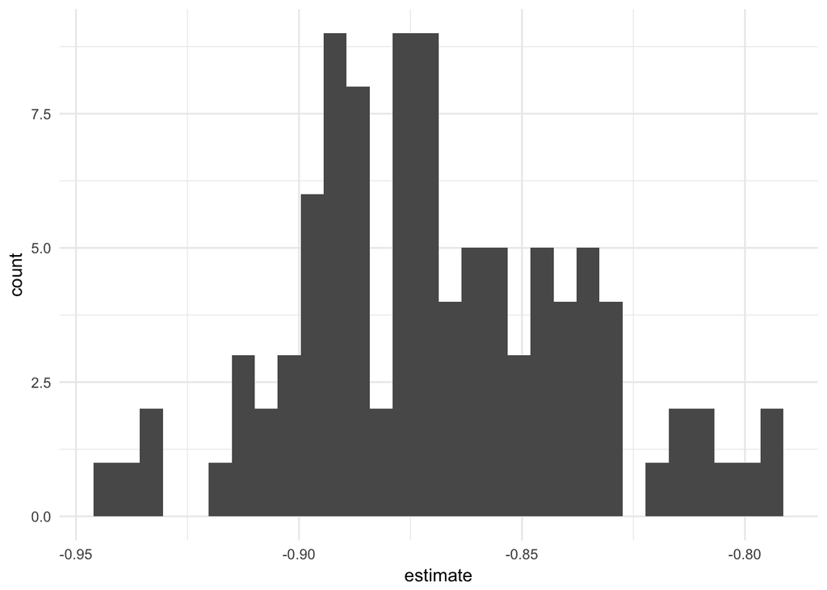

```r
mtcars %>%
  broom::bootstrap(100) %>%
  do(glance(cor.test(.$wt, .$mpg))) %>%
  ggplot(aes(estimate)) +
  geom_histogram() +
  theme_minimal()
```

#### :: hypothesis testing with permutations

(Note that I can’t get this to work with `cor.test` so I’m using `lm` instead):

```r
permuted <- mtcars %>%
  modelr::permute(100, mpg) %>%
  mutate(models = map(perm, ~ lm(mpg ~ wt, data = .))) %>%
  mutate(tidy = map(models, broom::glance)) %>%
  unnest(tidy)

head(permuted)
```

```
## # A tibble: 6 x 14
##                perm   .id   models    r.squared adj.r.squared    sigma
##              <list> <chr>   <list>        <dbl>         <dbl>    <dbl>
## 1 <S3: permutation>   001 <S3: lm> 0.0218728006 -0.0107314393 6.059201
## 2 <S3: permutation>   002 <S3: lm> 0.0096490274 -0.0233626717 6.096944
## 3 <S3: permutation>   003 <S3: lm> 0.0665444459  0.0354292607 5.919220
## 4 <S3: permutation>   004 <S3: lm> 0.0313487944 -0.0009395792 6.029779
## 5 <S3: permutation>   005 <S3: lm> 0.0011501744 -0.0321448198 6.123049
## 6 <S3: permutation>   006 <S3: lm> 0.0004927629 -0.0328241450 6.125064
## # ... with 8 more variables: statistic <dbl>, p.value <dbl>, df <int>,
## #   logLik <dbl>, AIC <dbl>, BIC <dbl>, deviance <dbl>, df.residual <int>
```

We can not check to make sure that the randomization has destroyed any corrleation that was initially apparent:

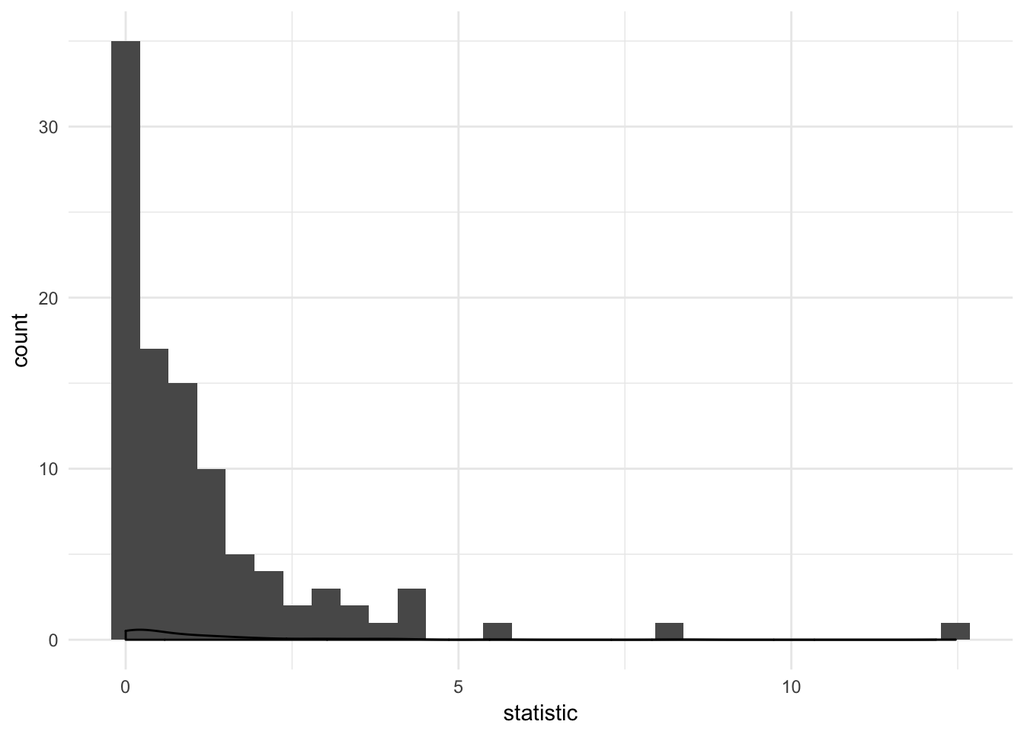

```r
permuted %>%
  ggplot(aes(x = statistic)) +
  geom_histogram() +
  geom_density() +
  theme_minimal()
```

And that the p-values are roughly uniform:

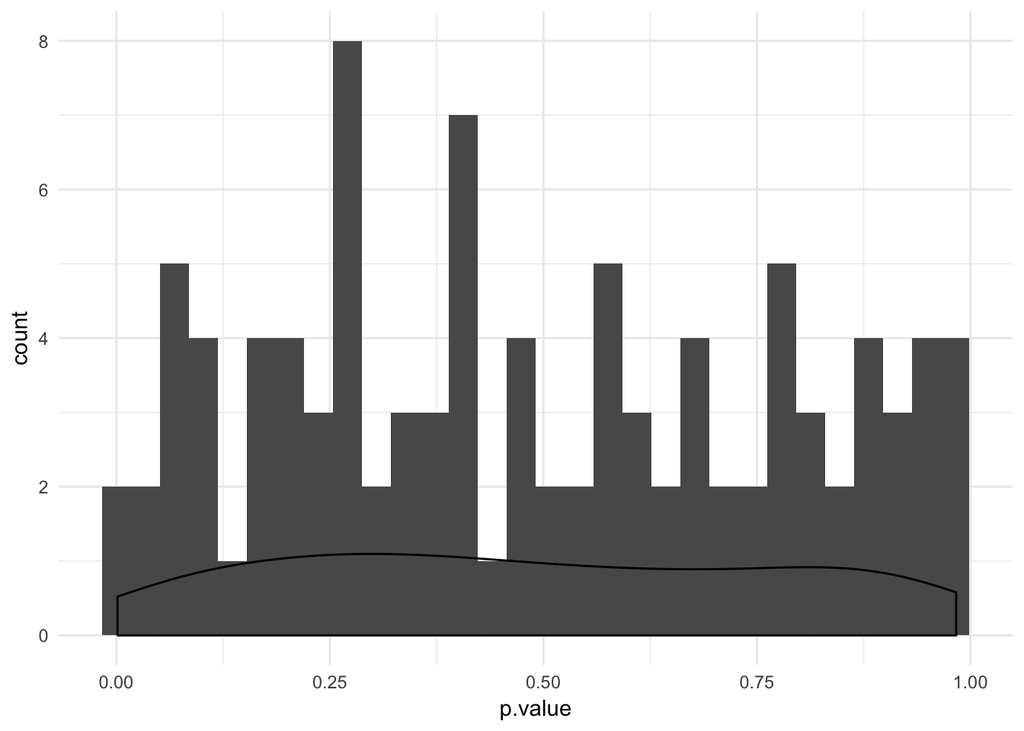

```r
permuted %>%
  ggplot(aes(x = p.value)) +
  geom_histogram() +
  geom_density() +
  theme_minimal()
```

From this, we can get a permutation-based p-value:

```r
mod <- lm(mpg ~ wt, mtcars)

(mean(permuted$statistic > broom::glance(mod)$statistic) + 1) / 100
```

```
## [1] 0.01
```

As expected (the correlation is strong) this gives us a low p-value (actually, this is the lowest p-value we could get by running 100 replicates).

```r
cor.test(mtcars$mpg, mtcars$wt)
```

```
##
##  Pearson's product-moment correlation
##
## data:  mtcars$mpg and mtcars$wt
## t = -9.559, df = 30, p-value = 1.294e-10
## alternative hypothesis: true correlation is not equal to 0
## 95 percent confidence interval:
##  -0.9338264 -0.7440872
## sample estimates:
##        cor
## -0.8676594
```

### t-tests

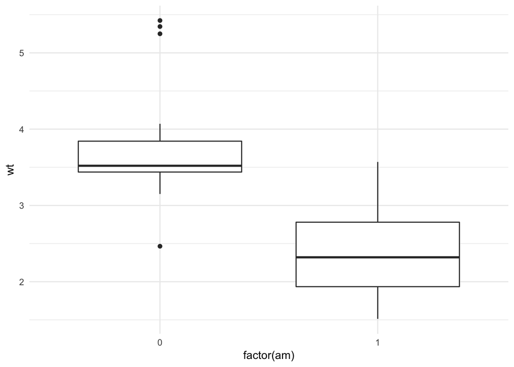

```r
mtcars %>%
  ggplot(aes(x = factor(am), y = wt)) +
  geom_boxplot() +
  theme_minimal()
```

Use a t-test just to get a sense of things:

```r
t.test(wt ~ factor(am), data = mtcars)
```

```
##
##  Welch Two Sample t-test
##
## data:  wt by factor(am)
## t = 5.4939, df = 29.234, p-value = 6.272e-06
## alternative hypothesis: true difference in means is not equal to 0
## 95 percent confidence interval:
##  0.8525632 1.8632262
## sample estimates:
## mean in group 0 mean in group 1
##        3.768895        2.411000
```

Do the permuting. Get the difference between the two groups instead of running t-test

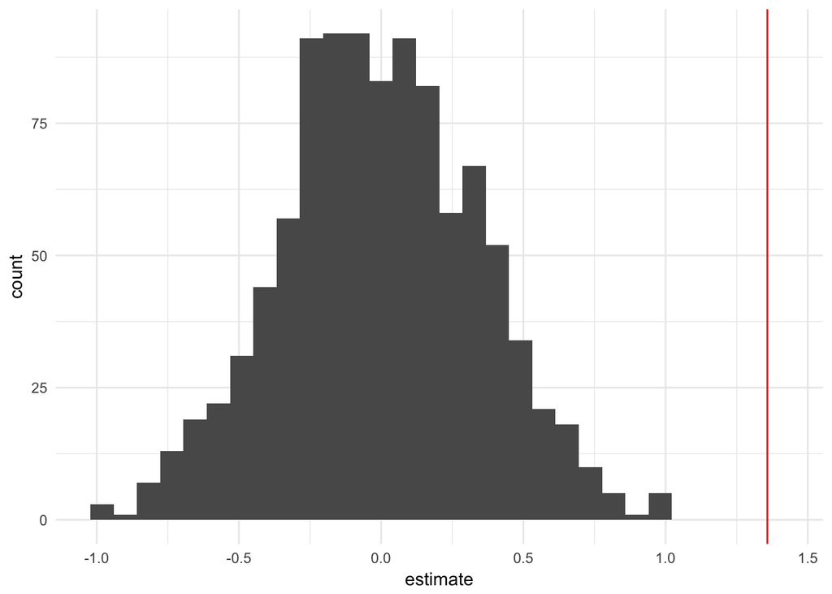

```r
# number of permutations
n <- 999

permuted <- mtcars %>%
  mutate(am = factor(am)) %>%
  modelr::permute(n, am) %>%
  mutate(models = map(perm, ~ t.test(wt ~ am, data = .))) %>%
  mutate(tidy = map(models, broom::glance)) %>%
  unnest(tidy)

observed <- broom::glance(t.test(wt ~ factor(am), data = mtcars))$estimate

ggplot(permuted, aes(x = estimate)) +
  geom_histogram() +
  geom_vline(xintercept = observed, color = "red") +
  theme_minimal()
```

```r
mean(permuted$estimate) # around 0, as expected
```

```
## [1] -0.005581906
```

```r
mod <- t.test(wt ~ factor(am), data = mtcars)

(sum(abs(permuted$estimate) > ifelse(observed > 0, observed, -observed)) + 1) / (n+1)
```

```
## [1] 0.001
```